# Predict Bike Sharing Demand with AutoGluon Template

## Project: Predict Bike Sharing Demand with AutoGluon

This notebook is a template with each step that you need to complete for the project.

Please fill in your code where there are explicit `?` markers in the notebook. You are welcome to add more cells and code as you see fit.

Once you have completed all the code implementations, please export your notebook as a HTML file so the reviews can view your code. Make sure you have all outputs correctly outputted.

`File-> Export Notebook As... -> Export Notebook as HTML`

There is a writeup to complete as well after all code implememtation is done. Please answer all questions and attach the necessary tables and charts. You can complete the writeup in either markdown or PDF.

Completing the code template and writeup template will cover all of the rubric points for this project.

The rubric contains "Stand Out Suggestions" for enhancing the project beyond the minimum requirements. The stand out suggestions are optional. If you decide to pursue the "stand out suggestions", you can include the code in this notebook and also discuss the results in the writeup file.

## Step 1: Create an account with Kaggle

### Create Kaggle Account and download API key

Below is example of steps to get the API username and key. Each student will have their own username and key.

1. Open account settings.

2. Scroll down to API and click Create New API Token.

3. Open up `kaggle.json` and use the username and key.


## Step 2: Download the Kaggle dataset using the kaggle python library

### Open up Sagemaker Studio and use starter template

1. Notebook should be using a `ml.t3.medium` instance (2 vCPU + 4 GiB)
2. Notebook should be using kernal: `Python 3 (MXNet 1.8 Python 3.7 CPU Optimized)`

```python
!pip3 install ipywidgets --user
```

```
WARNING: Running pip as the 'root' user can result in broken permissions and conflicting behaviour with the system package manager. It is recommended to use a virtual environment instead: https://pip.pypa.io/warnings/venv
```

### Install packages

```python
!pip install -U pip
!pip install -U setuptools wheel
!pip install -U "mxnet<2.0.0" bokeh==2.0.1
!pip install autogluon --no-cache-dir
# Without --no-cache-dir, smaller aws instances may have trouble installing
```

[output not shown]

### Setup Kaggle API Key

```python
# create the .kaggle directory and an empty kaggle.json file
!mkdir -p /root/.kaggle
!touch /root/.kaggle/kaggle.json
!chmod 600 /root/.kaggle/kaggle.json
```

```python
# Fill in your user name and key from creating the kaggle account and API token file
import json
kaggle_username = "hebaabdelhai"
kaggle_key = "4463a22cd13dc2b4f385d545824ddfd0"

# Save API token the kaggle.json file
with open("/root/.kaggle/kaggle.json", "w") as f:
    f.write(json.dumps({"username": kaggle_username, "key": kaggle_key}))
```

### Download and explore dataset

### Go to the bike sharing demand competition and agree to the terms

```python
# Download the dataset, it will be in a .zip file so you'll need to unzip it as well.
!kaggle competitions download -c bike-sharing-demand
# If you already downloaded it you can use the -o command to overwrite the file
!unzip -o bike-sharing-demand.zip
```

```
bike-sharing-demand.zip: Skipping, found more recently modified local copy (use --force to force download)
Archive:  bike-sharing-demand.zip
  inflating: sampleSubmission.csv
  inflating: test.csv
  inflating: train.csv
```

```python
import pandas as pd
from autogluon.tabular import TabularPredictor
```

```python
# Create the train dataset in pandas by reading the csv
# Set the parsing of the datetime column so you can use some of the `dt` features in pandas later
train = pd.read_csv("train.csv")
train.loc[:, "datetime"] = pd.to_datetime(train.loc[:, 'datetime'])
train.head()
```

|  | datetime | season | holiday | workingday | weather | temp | atemp | humidity | windspeed | casual | registered | count |
| --- | --- | --- | --- | --- | --- | --- | --- | --- | --- | --- | --- | --- |
| 0 | 2011-01-01 00:00:00 | 1 | 0 | 0 | 1 | 9.84 | 14.395 | 81 | 0.0 | 3 | 13 | 16 |
| 1 | 2011-01-01 01:00:00 | 1 | 0 | 0 | 1 | 9.02 | 13.635 | 80 | 0.0 | 8 | 32 | 40 |
| 2 | 2011-01-01 02:00:00 | 1 | 0 | 0 | 1 | 9.02 | 13.635 | 80 | 0.0 | 5 | 27 | 32 |
| 3 | 2011-01-01 03:00:00 | 1 | 0 | 0 | 1 | 9.84 | 14.395 | 75 | 0.0 | 3 | 10 | 13 |
| 4 | 2011-01-01 04:00:00 | 1 | 0 | 0 | 1 | 9.84 | 14.395 | 75 | 0.0 | 0 | 1 | 1 |

```python
# Simple output of the train dataset to view some of the min/max/varition of the dataset features.
train.describe()
```

|  | season | holiday | workingday | weather | temp | atemp | humidity | windspeed | casual | registered | count |
| --- | --- | --- | --- | --- | --- | --- | --- | --- | --- | --- | --- |
| count | 10886.000000 | 10886.000000 | 10886.000000 | 10886.000000 | 10886.00000 | 10886.000000 | 10886.000000 | 10886.000000 | 10886.000000 | 10886.000000 | 10886.000000 |
| mean | 2.506614 | 0.028569 | 0.680875 | 1.418427 | 20.23086 | 23.655084 | 61.886460 | 12.799395 | 36.021955 | 155.552177 | 191.574132 |
| std | 1.116174 | 0.166599 | 0.466159 | 0.633839 | 7.79159 | 8.474601 | 19.245033 | 8.164537 | 49.960477 | 151.039033 | 181.144454 |
| min | 1.000000 | 0.000000 | 0.000000 | 1.000000 | 0.82000 | 0.760000 | 0.000000 | 0.000000 | 0.000000 | 0.000000 | 1.000000 |
| 25% | 2.000000 | 0.000000 | 0.000000 | 1.000000 | 13.94000 | 16.665000 | 47.000000 | 7.001500 | 4.000000 | 36.000000 | 42.000000 |
| 50% | 3.000000 | 0.000000 | 1.000000 | 1.000000 | 20.50000 | 24.240000 | 62.000000 | 12.998000 | 17.000000 | 118.000000 | 145.000000 |
| 75% | 4.000000 | 0.000000 | 1.000000 | 2.000000 | 26.24000 | 31.060000 | 77.000000 | 16.997900 | 49.000000 | 222.000000 | 284.000000 |
| max | 4.000000 | 1.000000 | 1.000000 | 4.000000 | 41.00000 | 45.455000 | 100.000000 | 56.996900 | 367.000000 | 886.000000 | 977.000000 |

```python
# Create the test pandas dataframe in pandas by reading the csv, remember to parse the datetime!
test = pd.read_csv('test.csv')
test.loc[:, "datetime"] = pd.to_datetime(test.loc[:, "datetime"])
test.head()
#test.info()
```

|  | datetime | season | holiday | workingday | weather | temp | atemp | humidity | windspeed |
| --- | --- | --- | --- | --- | --- | --- | --- | --- | --- |
| 0 | 2011-01-20 00:00:00 | 1 | 0 | 1 | 1 | 10.66 | 11.365 | 56 | 26.0027 |
| 1 | 2011-01-20 01:00:00 | 1 | 0 | 1 | 1 | 10.66 | 13.635 | 56 | 0.0000 |
| 2 | 2011-01-20 02:00:00 | 1 | 0 | 1 | 1 | 10.66 | 13.635 | 56 | 0.0000 |
| 3 | 2011-01-20 03:00:00 | 1 | 0 | 1 | 1 | 10.66 | 12.880 | 56 | 11.0014 |
| 4 | 2011-01-20 04:00:00 | 1 | 0 | 1 | 1 | 10.66 | 12.880 | 56 | 11.0014 |

```python
# Same thing as train and test dataset
submission = pd.read_csv("sampleSubmission.csv")
submission.loc[:, "datetime"] = pd.to_datetime(submission.loc[:, "datetime"])
submission.head()
```

|  | datetime | count |
| --- | --- | --- |
| 0 | 2011-01-20 00:00:00 | 0 |
| 1 | 2011-01-20 01:00:00 | 0 |
| 2 | 2011-01-20 02:00:00 | 0 |
| 3 | 2011-01-20 03:00:00 | 0 |
| 4 | 2011-01-20 04:00:00 | 0 |

## Step 3: Train a model using AutoGluon’s Tabular Prediction

Requirements:

- We are prediting `count`, so it is the label we are setting.
- Ignore `casual` and `registered` columns as they are also not present in the test dataset.
- Use the `root_mean_squared_error` as the metric to use for evaluation.
- Set a time limit of 10 minutes (600 seconds).
- Use the preset `best_quality` to focus on creating the best model.

```python
train= train.drop(columns = ["registered", "casual"], axis=1)
predictor = TabularPredictor(label='count', eval_metric='root_mean_squared_error').fit(train_data= train, time_limit=600, presets='best_quality')
```

```
No path specified. Models will be saved in: "AutogluonModels/ag-20220214_002603/"
Presets specified: ['best_quality']
Beginning AutoGluon training ... Time limit = 600s
AutoGluon will save models to "AutogluonModels/ag-20220214_002603/"
AutoGluon Version:  0.3.1
Train Data Rows:    10886
Train Data Columns: 9
Preprocessing data ...
AutoGluon infers your prediction problem is: 'regression' (because dtype of label-column == int and many unique label-values observed).
	Label info (max, min, mean, stddev): (977, 1, 191.57413, 181.14445)
	If 'regression' is not the correct problem_type, please manually specify the problem_type argument in fit() (You may specify problem_type as one of: ['binary', 'multiclass', 'regression'])
Using Feature Generators to preprocess the data ...
Fitting AutoMLPipelineFeatureGenerator...
	Available Memory:                    894.48 MB
	Train Data (Original)  Memory Usage: 0.78 MB (0.1% of available memory)
	Inferring data type of each feature based on column values. Set feature_metadata_in to manually specify special dtypes of the features.
	Stage 1 Generators:
		Fitting AsTypeFeatureGenerator...
			Note: Converting 2 features to boolean dtype as they only contain 2 unique values.
	Stage 2 Generators:
		Fitting FillNaFeatureGenerator...
	Stage 3 Generators:
		Fitting IdentityFeatureGenerator...
		Fitting DatetimeFeatureGenerator...
	Stage 4 Generators:
		Fitting DropUniqueFeatureGenerator...
	Types of features in original data (raw dtype, special dtypes):
		('datetime', []) : 1 | ['datetime']
		('float', [])    : 3 | ['temp', 'atemp', 'windspeed']
		('int', [])      : 5 | ['season', 'holiday', 'workingday', 'weather', 'humidity']
	Types of features in processed data (raw dtype, special dtypes):
		('float', [])                : 3 | ['temp', 'atemp', 'windspeed']
		('int', [])                  : 3 | ['season', 'weather', 'humidity']
		('int', ['bool'])            : 2 | ['holiday', 'workingday']
		('int', ['datetime_as_int']) : 1 | ['datetime']
	0.1s = Fit runtime
	9 features in original data used to generate 9 features in processed data.
	Train Data (Processed) Memory Usage: 0.63 MB (0.1% of available memory)
Data preprocessing and feature engineering runtime = 0.14s ...
AutoGluon will gauge predictive performance using evaluation metric: 'root_mean_squared_error'
	To change this, specify the eval_metric argument of fit()
AutoGluon will fit 2 stack levels (L1 to L2) ...
Fitting 11 L1 models ...
Fitting model: KNeighborsUnif_BAG_L1 ... Training model for up to 399.81s of the 599.86s of remaining time.
	-160.4131	 = Validation score   (root_mean_squared_error)
	0.03s	 = Training   runtime
	0.1s	 = Validation runtime
Fitting model: KNeighborsDist_BAG_L1 ... Training model for up to 399.42s of the 599.47s of remaining time.
	-169.5521	 = Validation score   (root_mean_squared_error)
	0.02s	 = Training   runtime
	0.1s	 = Validation runtime
Fitting model: LightGBMXT_BAG_L1 ... Training model for up to 399.05s of the 599.11s of remaining time.
```

```
[1000]	train_set's rmse: 123.806	valid_set's rmse: 134.369
[2000]	train_set's rmse: 117.412	valid_set's rmse: 133.705
```

```
[1000]	train_set's rmse: 123.42	valid_set's rmse: 141.5
```

```
[1000]	train_set's rmse: 125.097	valid_set's rmse: 128.797
[2000]	train_set's rmse: 119.003	valid_set's rmse: 127.909
[3000]	train_set's rmse: 114.63	valid_set's rmse: 127.431
[4000]	train_set's rmse: 111.295	valid_set's rmse: 126.943
[5000]	train_set's rmse: 108.576	valid_set's rmse: 126.844
[6000]	train_set's rmse: 106.085	valid_set's rmse: 126.71
```

```
[1000]	train_set's rmse: 124.131	valid_set's rmse: 138.303
[2000]	train_set's rmse: 117.833	valid_set's rmse: 137.535
```

```
[1000]	train_set's rmse: 124.871	valid_set's rmse: 128.052
[2000]	train_set's rmse: 118.547	valid_set's rmse: 127.003
[3000]	train_set's rmse: 114.124	valid_set's rmse: 126.834
[4000]	train_set's rmse: 110.645	valid_set's rmse: 126.694
```

```
[1000]	train_set's rmse: 124.654	valid_set's rmse: 135.095
[2000]	train_set's rmse: 118.764	valid_set's rmse: 133.849
[3000]	train_set's rmse: 114.615	valid_set's rmse: 133.509
[4000]	train_set's rmse: 111.249	valid_set's rmse: 133.472
[5000]	train_set's rmse: 108.455	valid_set's rmse: 133.281
```

```
[1000]	train_set's rmse: 124.01	valid_set's rmse: 139.355
[2000]	train_set's rmse: 117.819	valid_set's rmse: 138.312
[3000]	train_set's rmse: 113.4	valid_set's rmse: 137.886
[4000]	train_set's rmse: 110.032	valid_set's rmse: 137.758
```

```
[1000]	train_set's rmse: 124.47	valid_set's rmse: 135.412
```

```
[1000]	train_set's rmse: 124.18	valid_set's rmse: 137.579
[2000]	train_set's rmse: 117.782	valid_set's rmse: 136.664
[3000]	train_set's rmse: 113.447	valid_set's rmse: 136.246
[4000]	train_set's rmse: 109.982	valid_set's rmse: 136.227
```

```
[1000]	train_set's rmse: 124.641	valid_set's rmse: 132.484
```

```
	-134.0883	 = Validation score   (root_mean_squared_error)
	49.13s	 = Training   runtime
	2.12s	 = Validation runtime
Fitting model: LightGBM_BAG_L1 ... Training model for up to 342.22s of the 542.27s of remaining time.
```

```
[1000]	train_set's rmse: 96.0217	valid_set's rmse: 123.249
```

```
[1000]	train_set's rmse: 94.7479	valid_set's rmse: 135.635
```

```
[1000]	train_set's rmse: 95.3055	valid_set's rmse: 132.087
```

```
[1000]	train_set's rmse: 95.1635	valid_set's rmse: 131.521
```

[output not shown]

[output cut: 87 more lines]

```
	112.05s	 = Training   runtime
	0.36s	 = Validation runtime
Fitting model: XGBoost_BAG_L2 ... Training model for up to 12.01s of the 11.99s of remaining time.
	-118.507	 = Validation score   (root_mean_squared_error)
	10.99s	 = Training   runtime
	0.07s	 = Validation runtime
Fitting model: NeuralNetMXNet_BAG_L2 ... Training model for up to 0.01s of the -0.01s of remaining time.
	Time limit exceeded... Skipping NeuralNetMXNet_BAG_L2.
Completed 1/20 k-fold bagging repeats ...
Fitting model: WeightedEnsemble_L3 ... Training model for up to 360.0s of the -1.39s of remaining time.
	-116.1875	 = Validation score   (root_mean_squared_error)
	0.36s	 = Training   runtime
	0.0s	 = Validation runtime
AutoGluon training complete, total runtime = 601.97s ...
TabularPredictor saved. To load, use: predictor = TabularPredictor.load("AutogluonModels/ag-20220214_002603/")
```

### Review AutoGluon's training run with ranking of models that did the best.

```python
predictor.fit_summary()
```

```
*** Summary of fit() ***
Estimated performance of each model:
                     model   score_val  pred_time_val    fit_time  pred_time_val_marginal  fit_time_marginal  stack_level  can_infer  fit_order
0      WeightedEnsemble_L3 -116.187513      10.343643  524.417383                0.000659           0.355180            3       True         19
1   NeuralNetFastAI_BAG_L2 -116.950889       9.746454  484.581965                0.357797         112.047831            2       True         17
2        LightGBMXT_BAG_L2 -117.101585       9.595762  386.798049                0.207105          14.263915            2       True         12
3          CatBoost_BAG_L2 -117.727897       9.429632  398.960429                0.040976          26.426295            2       True         15
4          LightGBM_BAG_L2 -118.113846       9.455039  383.257448                0.066383          10.723314            2       True         13
5           XGBoost_BAG_L2 -118.507035       9.462441  383.527970                0.073784          10.993835            2       True         18
6      WeightedEnsemble_L2 -119.016168       5.936794  110.070748                0.000655           0.503831            2       True         11
7   RandomForestMSE_BAG_L1 -119.097217       0.193639    3.582015                0.193639           3.582015            1       True          5
8     ExtraTreesMSE_BAG_L2 -119.310475       9.637915  376.033308                0.249258           3.499173            2       True         16
9   RandomForestMSE_BAG_L2 -121.512157       9.656881  389.251993                0.268224          16.717858            2       True         14
10    ExtraTreesMSE_BAG_L1 -129.298744       0.202069    1.682222                0.202069           1.682222            1       True          7
11         LightGBM_BAG_L1 -132.286410       0.429246   17.019018                0.429246          17.019018            1       True          4
12          XGBoost_BAG_L1 -132.308522       0.144379   14.533358                0.144379          14.533358            1       True          9
13         CatBoost_BAG_L1 -132.349692       0.046788   58.841388                0.046788          58.841388            1       True          6
14       LightGBMXT_BAG_L1 -134.088334       2.118889   49.128632                2.118889          49.128632            1       True          3
15  NeuralNetFastAI_BAG_L1 -138.201911       0.304032  121.710527                0.304032         121.710527            1       True          8
16   NeuralNetMXNet_BAG_L1 -143.269594       5.742501  105.984901                5.742501         105.984901            1       True         10
17   KNeighborsUnif_BAG_L1 -160.413078       0.103041    0.031528                0.103041           0.031528            1       True          1
18   KNeighborsDist_BAG_L1 -169.552096       0.104074    0.020546                0.104074           0.020546            1       True          2
Number of models trained: 19
Types of models trained:
{'StackerEnsembleModel_CatBoost', 'StackerEnsembleModel_RF', 'StackerEnsembleModel_KNN', 'StackerEnsembleModel_TabularNeuralNet', 'StackerEnsembleModel_XT', 'StackerEnsembleModel_NNFastAiTabular', 'StackerEnsembleModel_LGB', 'StackerEnsembleModel_XGBoost', 'WeightedEnsembleModel'}
Bagging used: True  (with 10 folds)
Multi-layer stack-ensembling used: True  (with 3 levels)
Feature Metadata (Processed):
(raw dtype, special dtypes):
('float', [])                : 3 | ['temp', 'atemp', 'windspeed']
('int', [])                  : 3 | ['season', 'weather', 'humidity']
('int', ['bool'])            : 2 | ['holiday', 'workingday']
('int', ['datetime_as_int']) : 1 | ['datetime']
Plot summary of models saved to file: AutogluonModels/ag-20220214_002603/SummaryOfModels.html
*** End of fit() summary ***
```

```
{'model_types': {'KNeighborsUnif_BAG_L1': 'StackerEnsembleModel_KNN',
  'KNeighborsDist_BAG_L1': 'StackerEnsembleModel_KNN',
  'LightGBMXT_BAG_L1': 'StackerEnsembleModel_LGB',
  'LightGBM_BAG_L1': 'StackerEnsembleModel_LGB',
  'RandomForestMSE_BAG_L1': 'StackerEnsembleModel_RF',
  'CatBoost_BAG_L1': 'StackerEnsembleModel_CatBoost',
  'ExtraTreesMSE_BAG_L1': 'StackerEnsembleModel_XT',
  'NeuralNetFastAI_BAG_L1': 'StackerEnsembleModel_NNFastAiTabular',
  'XGBoost_BAG_L1': 'StackerEnsembleModel_XGBoost',
  'NeuralNetMXNet_BAG_L1': 'StackerEnsembleModel_TabularNeuralNet',
  'WeightedEnsemble_L2': 'WeightedEnsembleModel',
  'LightGBMXT_BAG_L2': 'StackerEnsembleModel_LGB',
  'LightGBM_BAG_L2': 'StackerEnsembleModel_LGB',
  'RandomForestMSE_BAG_L2': 'StackerEnsembleModel_RF',
  'CatBoost_BAG_L2': 'StackerEnsembleModel_CatBoost',
  'ExtraTreesMSE_BAG_L2': 'StackerEnsembleModel_XT',
  'NeuralNetFastAI_BAG_L2': 'StackerEnsembleModel_NNFastAiTabular',
  'XGBoost_BAG_L2': 'StackerEnsembleModel_XGBoost',
  'WeightedEnsemble_L3': 'WeightedEnsembleModel'},
 'model_performance': {'KNeighborsUnif_BAG_L1': -160.4130779463501,
  'KNeighborsDist_BAG_L1': -169.55209635208928,
  'LightGBMXT_BAG_L1': -134.08833420116997,
  'LightGBM_BAG_L1': -132.28640961443517,
  'RandomForestMSE_BAG_L1': -119.09721720000539,
  'CatBoost_BAG_L1': -132.34969157134555,
  'ExtraTreesMSE_BAG_L1': -129.29874435326832,
  'NeuralNetFastAI_BAG_L1': -138.20191109637813,
  'XGBoost_BAG_L1': -132.30852184526813,
  'NeuralNetMXNet_BAG_L1': -143.26959434687757,
  'WeightedEnsemble_L2': -119.01616774163004,
  'LightGBMXT_BAG_L2': -117.10158547885258,
  'LightGBM_BAG_L2': -118.11384569354466,
  'RandomForestMSE_BAG_L2': -121.51215674269936,
  'CatBoost_BAG_L2': -117.72789658731752,
  'ExtraTreesMSE_BAG_L2': -119.31047512793408,
  'NeuralNetFastAI_BAG_L2': -116.95088869322049,
  'XGBoost_BAG_L2': -118.50703521863352,
  'WeightedEnsemble_L3': -116.18751251685921},
 'model_best': 'WeightedEnsemble_L3',
 'model_paths': {'KNeighborsUnif_BAG_L1': 'AutogluonModels/ag-20220214_002603/models/KNeighborsUnif_BAG_L1/',
```

[output cut: 187 more lines]

```
 4          13
 5          18
 6          11
 7           5
 8          16
 9          14
 10          7
 11          4
 12          9
 13          6
 14          3
 15          8
 16         10
 17          1
 18          2  }
```

### Create predictions from test dataset

```python
predictions = predictor.predict(test)
predictions.head()
```

```
0     85.756836
1     92.820969
2     92.821838
3    104.227150
4    104.228172
Name: count, dtype: float32
```

#### NOTE: Kaggle will reject the submission if we don't set everything to be > 0.

```python
# Describe the `predictions` series to see if there are any negative val
predictions.describe()
```

```
count    6493.000000
mean      210.761566
std       128.573120
min        -9.998586
25%       108.220062
50%       195.057495
75%       295.917511
max       650.510376
Name: count, dtype: float64
```

```python
# How many negative values do we have?

sum =0
for prediction in predictions:
    if prediction<0:
        sum +=1
print(sum)
```

```
1
```

```python
# Set them to zero
predictions.loc[predictions<0]= 0
```

### Set predictions to submission dataframe, save, and submit

```python
submission["count"] = predictions
submission.to_csv("submission.csv", index=False)
```

```python
!kaggle competitions submit -c bike-sharing-demand -f submission.csv -m "first raw submission"
```

```
Successfully submitted to Bike Sharing Demand
```

#### View submission via the command line or in the web browser under the competition's page - `My Submissions`

```python
!kaggle competitions submissions -c bike-sharing-demand | tail -n +1 | head -n 6
```

```
fileName                     date                 description                          status    publicScore  privateScore
---------------------------  -------------------  -----------------------------------  --------  -----------  ------------
submission.csv               2022-02-14 00:38:20  first raw submission                 complete  1.38918      1.38918
submission_sto_features.csv  2022-02-13 22:59:03  standout suggestion hyperparameters  complete  0.47203      0.47203
submission_sto_features.csv  2022-02-13 22:32:00  standout suggestion new features     complete  0.47203      0.47203
submission_sto_features.csv  2022-02-13 22:31:23  standout suggestion new features     complete  0.47203      0.47203
```

## Step 4: Exploratory Data Analysis and Creating an additional feature

- Any additional feature will do, but a great suggestion would be to separate out the datetime into hour, day, or month parts.

```
array([[<AxesSubplot:title={'center':'datetime'}>,
        <AxesSubplot:title={'center':'season'}>,
        <AxesSubplot:title={'center':'holiday'}>],
       [<AxesSubplot:title={'center':'workingday'}>,
        <AxesSubplot:title={'center':'weather'}>,
        <AxesSubplot:title={'center':'temp'}>],
       [<AxesSubplot:title={'center':'atemp'}>,
        <AxesSubplot:title={'center':'humidity'}>,
        <AxesSubplot:title={'center':'windspeed'}>],
       [<AxesSubplot:title={'center':'count'}>, <AxesSubplot:>,
        <AxesSubplot:>]], dtype=object)
```

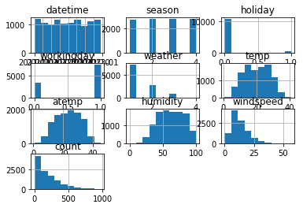

```python
# Create a histogram of all features to show the distribution of each one relative to the data. This is part of the exploritory data analysis
train.hist()
```

```python
# create a new feature
train["year"] = train.datetime.dt.year
test["year"] = test.datetime.dt.year
train.head()
```

|  | datetime | season | holiday | workingday | weather | temp | atemp | humidity | windspeed | count | year |
| --- | --- | --- | --- | --- | --- | --- | --- | --- | --- | --- | --- |
| 0 | 2011-01-01 00:00:00 | 1 | 0 | 0 | 1 | 9.84 | 14.395 | 81 | 0.0 | 16 | 2011 |
| 1 | 2011-01-01 01:00:00 | 1 | 0 | 0 | 1 | 9.02 | 13.635 | 80 | 0.0 | 40 | 2011 |
| 2 | 2011-01-01 02:00:00 | 1 | 0 | 0 | 1 | 9.02 | 13.635 | 80 | 0.0 | 32 | 2011 |
| 3 | 2011-01-01 03:00:00 | 1 | 0 | 0 | 1 | 9.84 | 14.395 | 75 | 0.0 | 13 | 2011 |
| 4 | 2011-01-01 04:00:00 | 1 | 0 | 0 | 1 | 9.84 | 14.395 | 75 | 0.0 | 1 | 2011 |

## Make category types for these so models know they are not just numbers

- AutoGluon originally sees these as ints, but in reality they are int representations of a category.
- Setting the dtype to category will classify these as categories in AutoGluon.

```python
train["season"] = train["season"].astype("category")
train["weather"] = train["weather"].astype("category")
test["season"] = test["season"].astype("category")
test["weather"] = test["weather"].astype("category")
train.info()
```

```
<class 'pandas.core.frame.DataFrame'>
RangeIndex: 10886 entries, 0 to 10885
Data columns (total 11 columns):
 #   Column      Non-Null Count  Dtype
---  ------      --------------  -----
 0   datetime    10886 non-null  datetime64[ns]
 1   season      10886 non-null  category
 2   holiday     10886 non-null  int64
 3   workingday  10886 non-null  int64
 4   weather     10886 non-null  category
 5   temp        10886 non-null  float64
 6   atemp       10886 non-null  float64
 7   humidity    10886 non-null  int64
 8   windspeed   10886 non-null  float64
 9   count       10886 non-null  int64
 10  year        10886 non-null  int64
dtypes: category(2), datetime64[ns](1), float64(3), int64(5)
memory usage: 787.2 KB
```

```python
# View are new feature
train.head()
```

|  | datetime | season | holiday | workingday | weather | temp | atemp | humidity | windspeed | count | year |
| --- | --- | --- | --- | --- | --- | --- | --- | --- | --- | --- | --- |
| 0 | 2011-01-01 00:00:00 | 1 | 0 | 0 | 1 | 9.84 | 14.395 | 81 | 0.0 | 16 | 2011 |
| 1 | 2011-01-01 01:00:00 | 1 | 0 | 0 | 1 | 9.02 | 13.635 | 80 | 0.0 | 40 | 2011 |
| 2 | 2011-01-01 02:00:00 | 1 | 0 | 0 | 1 | 9.02 | 13.635 | 80 | 0.0 | 32 | 2011 |
| 3 | 2011-01-01 03:00:00 | 1 | 0 | 0 | 1 | 9.84 | 14.395 | 75 | 0.0 | 13 | 2011 |
| 4 | 2011-01-01 04:00:00 | 1 | 0 | 0 | 1 | 9.84 | 14.395 | 75 | 0.0 | 1 | 2011 |

```
array([[<AxesSubplot:title={'center':'datetime'}>,
        <AxesSubplot:title={'center':'holiday'}>,
        <AxesSubplot:title={'center':'workingday'}>],
       [<AxesSubplot:title={'center':'temp'}>,
        <AxesSubplot:title={'center':'atemp'}>,
        <AxesSubplot:title={'center':'humidity'}>],
       [<AxesSubplot:title={'center':'windspeed'}>,
        <AxesSubplot:title={'center':'count'}>,
        <AxesSubplot:title={'center':'year'}>],
       [<AxesSubplot:title={'center':'hour'}>, <AxesSubplot:>,
        <AxesSubplot:>]], dtype=object)
```

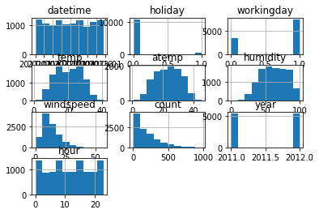

```python
# View histogram of all features again now with the hour feature
train['hour'] = train.datetime.dt.hour
train.hist()
```

## Step 5: Rerun the model with the same settings as before, just with more features

```python
train['month'] = train.datetime.dt.month
train['day'] = train.datetime.dt.day

predictor_new_features = TabularPredictor(label='count', eval_metric='root_mean_squared_error').fit(train_data= train, time_limit=600, presets='best_quality')
```

```
No path specified. Models will be saved in: "AutogluonModels/ag-20220214_003943/"
Presets specified: ['best_quality']
Beginning AutoGluon training ... Time limit = 600s
AutoGluon will save models to "AutogluonModels/ag-20220214_003943/"
AutoGluon Version:  0.3.1
Train Data Rows:    10886
Train Data Columns: 13
Preprocessing data ...
AutoGluon infers your prediction problem is: 'regression' (because dtype of label-column == int and many unique label-values observed).
	Label info (max, min, mean, stddev): (977, 1, 191.57413, 181.14445)
	If 'regression' is not the correct problem_type, please manually specify the problem_type argument in fit() (You may specify problem_type as one of: ['binary', 'multiclass', 'regression'])
Using Feature Generators to preprocess the data ...
Fitting AutoMLPipelineFeatureGenerator...
	Available Memory:                    1001.03 MB
	Train Data (Original)  Memory Usage: 0.98 MB (0.1% of available memory)
	Inferring data type of each feature based on column values. Set feature_metadata_in to manually specify special dtypes of the features.
	Stage 1 Generators:
		Fitting AsTypeFeatureGenerator...
			Note: Converting 3 features to boolean dtype as they only contain 2 unique values.
	Stage 2 Generators:
		Fitting FillNaFeatureGenerator...
	Stage 3 Generators:
		Fitting IdentityFeatureGenerator...
		Fitting CategoryFeatureGenerator...
			Fitting CategoryMemoryMinimizeFeatureGenerator...
		Fitting DatetimeFeatureGenerator...
	Stage 4 Generators:
		Fitting DropUniqueFeatureGenerator...
	Types of features in original data (raw dtype, special dtypes):
		('category', []) : 2 | ['season', 'weather']
		('datetime', []) : 1 | ['datetime']
		('float', [])    : 3 | ['temp', 'atemp', 'windspeed']
		('int', [])      : 7 | ['holiday', 'workingday', 'humidity', 'year', 'hour', ...]
	Types of features in processed data (raw dtype, special dtypes):
		('category', [])             : 2 | ['season', 'weather']
		('float', [])                : 3 | ['temp', 'atemp', 'windspeed']
		('int', [])                  : 4 | ['humidity', 'hour', 'month', 'day']
		('int', ['bool'])            : 3 | ['holiday', 'workingday', 'year']
		('int', ['datetime_as_int']) : 1 | ['datetime']
	0.2s = Fit runtime
	13 features in original data used to generate 13 features in processed data.
	Train Data (Processed) Memory Usage: 0.75 MB (0.1% of available memory)
Data preprocessing and feature engineering runtime = 0.22s ...
AutoGluon will gauge predictive performance using evaluation metric: 'root_mean_squared_error'
	To change this, specify the eval_metric argument of fit()
AutoGluon will fit 2 stack levels (L1 to L2) ...
Fitting 11 L1 models ...
Fitting model: KNeighborsUnif_BAG_L1 ... Training model for up to 399.75s of the 599.77s of remaining time.
	-123.9226	 = Validation score   (root_mean_squared_error)
	0.03s	 = Training   runtime
	0.2s	 = Validation runtime
Fitting model: KNeighborsDist_BAG_L1 ... Training model for up to 399.27s of the 599.29s of remaining time.
	-119.3734	 = Validation score   (root_mean_squared_error)
	0.02s	 = Training   runtime
	0.2s	 = Validation runtime
Fitting model: LightGBMXT_BAG_L1 ... Training model for up to 398.8s of the 598.82s of remaining time.
```

```
[1000]	train_set's rmse: 30.2477	valid_set's rmse: 37.5245
[2000]	train_set's rmse: 25.3001	valid_set's rmse: 36.0436
[3000]	train_set's rmse: 22.5451	valid_set's rmse: 35.7329
[4000]	train_set's rmse: 20.604	valid_set's rmse: 35.5579
[5000]	train_set's rmse: 19.0933	valid_set's rmse: 35.5226
```

```
[1000]	train_set's rmse: 30.2855	valid_set's rmse: 41.5672
[2000]	train_set's rmse: 25.4432	valid_set's rmse: 39.4708
[3000]	train_set's rmse: 22.7451	valid_set's rmse: 38.63
[4000]	train_set's rmse: 20.83	valid_set's rmse: 38.1891
[5000]	train_set's rmse: 19.3595	valid_set's rmse: 37.9911
[6000]	train_set's rmse: 18.078	valid_set's rmse: 37.8675
[7000]	train_set's rmse: 17.0434	valid_set's rmse: 37.7975
[8000]	train_set's rmse: 16.1117	valid_set's rmse: 37.714
[9000]	train_set's rmse: 15.2917	valid_set's rmse: 37.6917
[10000]	train_set's rmse: 14.5662	valid_set's rmse: 37.6263
```

```
[1000]	train_set's rmse: 30.5723	valid_set's rmse: 35.183
[2000]	train_set's rmse: 25.5654	valid_set's rmse: 34.1873
[3000]	train_set's rmse: 22.8284	valid_set's rmse: 34.1413
```

```
[1000]	train_set's rmse: 30.1978	valid_set's rmse: 40.8555
[2000]	train_set's rmse: 25.2874	valid_set's rmse: 39.2459
[3000]	train_set's rmse: 22.6566	valid_set's rmse: 38.7255
[4000]	train_set's rmse: 20.7635	valid_set's rmse: 38.4024
[5000]	train_set's rmse: 19.3121	valid_set's rmse: 38.2055
[6000]	train_set's rmse: 18.0987	valid_set's rmse: 38.0455
[7000]	train_set's rmse: 17.0244	valid_set's rmse: 37.8859
[8000]	train_set's rmse: 16.1316	valid_set's rmse: 37.7573
[9000]	train_set's rmse: 15.3347	valid_set's rmse: 37.6728
[10000]	train_set's rmse: 14.6031	valid_set's rmse: 37.6167
```

```
[1000]	train_set's rmse: 30.5834	valid_set's rmse: 38.3338
[2000]	train_set's rmse: 25.368	valid_set's rmse: 36.8213
[3000]	train_set's rmse: 22.6318	valid_set's rmse: 36.4373
[4000]	train_set's rmse: 20.688	valid_set's rmse: 36.3476
```

```
[1000]	train_set's rmse: 30.0456	valid_set's rmse: 41.6063
[2000]	train_set's rmse: 25.2807	valid_set's rmse: 40.4318
[3000]	train_set's rmse: 22.5682	valid_set's rmse: 40.2374
```

```
[1000]	train_set's rmse: 30.6638	valid_set's rmse: 39.008
[2000]	train_set's rmse: 25.6578	valid_set's rmse: 36.2636
[3000]	train_set's rmse: 22.9076	valid_set's rmse: 35.3631
[4000]	train_set's rmse: 20.8966	valid_set's rmse: 34.9365
[5000]	train_set's rmse: 19.3187	valid_set's rmse: 34.7854
[6000]	train_set's rmse: 18.0319	valid_set's rmse: 34.6856
[7000]	train_set's rmse: 16.9637	valid_set's rmse: 34.7055
```

```
[1000]	train_set's rmse: 30.2841	valid_set's rmse: 38.6973
[2000]	train_set's rmse: 25.3801	valid_set's rmse: 37.3003
[3000]	train_set's rmse: 22.6615	valid_set's rmse: 36.9534
[4000]	train_set's rmse: 20.748	valid_set's rmse: 36.7291
[5000]	train_set's rmse: 19.2405	valid_set's rmse: 36.5964
[6000]	train_set's rmse: 17.961	valid_set's rmse: 36.4937
[7000]	train_set's rmse: 16.912	valid_set's rmse: 36.4327
[8000]	train_set's rmse: 16.0178	valid_set's rmse: 36.4359
[9000]	train_set's rmse: 15.226	valid_set's rmse: 36.4932
```

```
[1000]	train_set's rmse: 30.2788	valid_set's rmse: 41.6075
[2000]	train_set's rmse: 25.3554	valid_set's rmse: 40.4776
[3000]	train_set's rmse: 22.6646	valid_set's rmse: 40.3757
```

```
[1000]	train_set's rmse: 30.9236	valid_set's rmse: 36.9172
[2000]	train_set's rmse: 25.7371	valid_set's rmse: 34.9063
[3000]	train_set's rmse: 22.9803	valid_set's rmse: 34.4039
[4000]	train_set's rmse: 21.0473	valid_set's rmse: 34.1593
[5000]	train_set's rmse: 19.5384	valid_set's rmse: 33.9918
[6000]	train_set's rmse: 18.2716	valid_set's rmse: 33.9458
[7000]	train_set's rmse: 17.2106	valid_set's rmse: 33.8961
[8000]	train_set's rmse: 16.2805	valid_set's rmse: 33.882
```

```
	-36.7176	 = Validation score   (root_mean_squared_error)
	100.05s	 = Training   runtime
	4.65s	 = Validation runtime
Fitting model: LightGBM_BAG_L1 ... Training model for up to 283.12s of the 483.14s of remaining time.
```

```
[1000]	train_set's rmse: 21.1363	valid_set's rmse: 35.556
[2000]	train_set's rmse: 15.5229	valid_set's rmse: 35.4489
```

```
[1000]	train_set's rmse: 21.0431	valid_set's rmse: 36.9388
[2000]	train_set's rmse: 15.5393	valid_set's rmse: 36.1223
[3000]	train_set's rmse: 12.2068	valid_set's rmse: 35.9677
[4000]	train_set's rmse: 9.97753	valid_set's rmse: 35.9639
```

```
[1000]	train_set's rmse: 21.4253	valid_set's rmse: 33.0295
```

```
[1000]	train_set's rmse: 21.4591	valid_set's rmse: 38.0987
[2000]	train_set's rmse: 15.6967	valid_set's rmse: 37.1129
[3000]	train_set's rmse: 12.2044	valid_set's rmse: 36.7212
[4000]	train_set's rmse: 9.95476	valid_set's rmse: 36.6786
```

```
[1000]	train_set's rmse: 21.43	valid_set's rmse: 37.371
[2000]	train_set's rmse: 15.5136	valid_set's rmse: 36.986
```

```
[1000]	train_set's rmse: 21.6619	valid_set's rmse: 35.9541
```

```
[1000]	train_set's rmse: 21.0051	valid_set's rmse: 35.6024
[2000]	train_set's rmse: 15.4015	valid_set's rmse: 34.9824
```

```
[1000]	train_set's rmse: 21.3287	valid_set's rmse: 36.3245
[2000]	train_set's rmse: 15.6834	valid_set's rmse: 35.8282
[3000]	train_set's rmse: 12.2992	valid_set's rmse: 35.5694
[4000]	train_set's rmse: 10.1773	valid_set's rmse: 35.5318
```

```
	-36.5863	 = Validation score   (root_mean_squared_error)
	38.6s	 = Training   runtime
	1.34s	 = Validation runtime
Fitting model: RandomForestMSE_BAG_L1 ... Training model for up to 239.02s of the 439.04s of remaining time.
	Warning: Reducing model 'n_estimators' from 300 -> 181 due to low memory. Expected memory usage reduced from 24.81% -> 15.0% of available memory...
	-41.6034	 = Validation score   (root_mean_squared_error)
	6.0s	 = Training   runtime
	0.24s	 = Validation runtime
Fitting model: CatBoost_BAG_L1 ... Training model for up to 231.64s of the 431.66s of remaining time.
	Time limit exceeded... Skipping CatBoost_BAG_L1.
Fitting model: ExtraTreesMSE_BAG_L1 ... Training model for up to 204.07s of the 404.1s of remaining time.
	Warning: Reducing model 'n_estimators' from 300 -> 172 due to low memory. Expected memory usage reduced from 26.02% -> 15.0% of available memory...
	-41.3856	 = Validation score   (root_mean_squared_error)
	2.29s	 = Training   runtime
	0.23s	 = Validation runtime
Fitting model: NeuralNetFastAI_BAG_L1 ... Training model for up to 200.47s of the 400.5s of remaining time.
	-45.7571	 = Validation score   (root_mean_squared_error)
	128.68s	 = Training   runtime
	0.34s	 = Validation runtime
Fitting model: XGBoost_BAG_L1 ... Training model for up to 70.65s of the 270.67s of remaining time.
	-37.4173	 = Validation score   (root_mean_squared_error)
	32.97s	 = Training   runtime
	0.32s	 = Validation runtime
Fitting model: NeuralNetMXNet_BAG_L1 ... Training model for up to 33.95s of the 233.97s of remaining time.
	Ran out of time, stopping training early. (Stopping on epoch 0)
	Ran out of time, stopping training early. (Stopping on epoch 0)
	Ran out of time, stopping training early. (Stopping on epoch 0)
	Ran out of time, stopping training early. (Stopping on epoch 0)
	Ran out of time, stopping training early. (Stopping on epoch 0)
	Ran out of time, stopping training early. (Stopping on epoch 1)
	Ran out of time, stopping training early. (Stopping on epoch 0)
	Ran out of time, stopping training early. (Stopping on epoch 0)
	Ran out of time, stopping training early. (Stopping on epoch 1)
	Ran out of time, stopping training early. (Stopping on epoch 1)
	-272.586	 = Validation score   (root_mean_squared_error)
	26.3s	 = Training   runtime
	6.18s	 = Validation runtime
Fitting model: LightGBMLarge_BAG_L1 ... Training model for up to 0.84s of the 200.87s of remaining time.
	Ran out of time, early stopping on iteration 1. Best iteration is:
	[1]	train_set's rmse: 176.305	valid_set's rmse: 174.668
```

[output cut: 38 more lines]

```
	Ran out of time, stopping training early. (Stopping on epoch 27)
	-35.7068	 = Validation score   (root_mean_squared_error)
	99.75s	 = Training   runtime
	0.38s	 = Validation runtime
Fitting model: XGBoost_BAG_L2 ... Training model for up to 5.46s of the 5.44s of remaining time.
	-36.1839	 = Validation score   (root_mean_squared_error)
	4.8s	 = Training   runtime
	0.11s	 = Validation runtime
Completed 1/20 k-fold bagging repeats ...
Fitting model: WeightedEnsemble_L3 ... Training model for up to 360.0s of the -0.2s of remaining time.
	-35.1073	 = Validation score   (root_mean_squared_error)
	0.36s	 = Training   runtime
	0.0s	 = Validation runtime
AutoGluon training complete, total runtime = 600.79s ...
TabularPredictor saved. To load, use: predictor = TabularPredictor.load("AutogluonModels/ag-20220214_003943/")
```

```python
predictor_new_features.fit_summary()
```

```
*** Summary of fit() ***
Estimated performance of each model:
                     model   score_val  pred_time_val    fit_time  pred_time_val_marginal  fit_time_marginal  stack_level  can_infer  fit_order
0      WeightedEnsemble_L3  -35.107319      14.807795  510.100203                0.000620           0.357307            3       True         18
1      WeightedEnsemble_L2  -35.141520       6.893460  306.741559                0.000715           0.427893            2       True         10
2          CatBoost_BAG_L2  -35.442516      13.778792  376.861258                0.066824          41.904965            2       True         14
3   NeuralNetFastAI_BAG_L2  -35.706838      14.093850  434.708078                0.381883          99.751785            2       True         16
4     ExtraTreesMSE_BAG_L2  -35.775805      13.978284  339.066884                0.266316           4.110591            2       True         15
5          LightGBM_BAG_L2  -35.783814      13.804816  346.844104                0.092849          11.887811            2       True         12
6   RandomForestMSE_BAG_L2  -36.046157      13.999303  352.087744                0.287335          17.131451            2       True         13
7           XGBoost_BAG_L2  -36.183898      13.823593  339.756528                0.111626           4.800235            2       True         17
8        LightGBMXT_BAG_L2  -36.244831      13.882111  348.241991                0.170144          13.285698            2       True         11
9          LightGBM_BAG_L1  -36.586278       1.340212   38.603559                1.340212          38.603559            1       True          4
10       LightGBMXT_BAG_L1  -36.717636       4.653201  100.054458                4.653201         100.054458            1       True          3
11          XGBoost_BAG_L1  -37.417259       0.315585   32.971392                0.315585          32.971392            1       True          8
12    ExtraTreesMSE_BAG_L1  -41.385601       0.233182    2.292770                0.233182           2.292770            1       True          6
13  RandomForestMSE_BAG_L1  -41.603381       0.242998    5.999713                0.242998           5.999713            1       True          5
14  NeuralNetFastAI_BAG_L1  -45.757071       0.340748  128.684544                0.340748         128.684544            1       True          7
15   KNeighborsDist_BAG_L1 -119.373394       0.203572    0.022261                0.203572           0.022261            1       True          2
16   KNeighborsUnif_BAG_L1 -123.922640       0.203217    0.029607                0.203217           0.029607            1       True          1
17   NeuralNetMXNet_BAG_L1 -272.585991       6.179252   26.297990                6.179252          26.297990            1       True          9
Number of models trained: 18
Types of models trained:
{'StackerEnsembleModel_TabularNeuralNet', 'StackerEnsembleModel_RF', 'StackerEnsembleModel_KNN', 'StackerEnsembleModel_CatBoost', 'StackerEnsembleModel_XT', 'StackerEnsembleModel_NNFastAiTabular', 'StackerEnsembleModel_LGB', 'StackerEnsembleModel_XGBoost', 'WeightedEnsembleModel'}
Bagging used: True  (with 10 folds)
Multi-layer stack-ensembling used: True  (with 3 levels)
Feature Metadata (Processed):
(raw dtype, special dtypes):
('category', [])             : 2 | ['season', 'weather']
('float', [])                : 3 | ['temp', 'atemp', 'windspeed']
('int', [])                  : 4 | ['humidity', 'hour', 'month', 'day']
('int', ['bool'])            : 3 | ['holiday', 'workingday', 'year']
('int', ['datetime_as_int']) : 1 | ['datetime']
Plot summary of models saved to file: AutogluonModels/ag-20220214_003943/SummaryOfModels.html
*** End of fit() summary ***
```

```
{'model_types': {'KNeighborsUnif_BAG_L1': 'StackerEnsembleModel_KNN',
  'KNeighborsDist_BAG_L1': 'StackerEnsembleModel_KNN',
  'LightGBMXT_BAG_L1': 'StackerEnsembleModel_LGB',
  'LightGBM_BAG_L1': 'StackerEnsembleModel_LGB',
  'RandomForestMSE_BAG_L1': 'StackerEnsembleModel_RF',
  'ExtraTreesMSE_BAG_L1': 'StackerEnsembleModel_XT',
  'NeuralNetFastAI_BAG_L1': 'StackerEnsembleModel_NNFastAiTabular',
  'XGBoost_BAG_L1': 'StackerEnsembleModel_XGBoost',
  'NeuralNetMXNet_BAG_L1': 'StackerEnsembleModel_TabularNeuralNet',
  'WeightedEnsemble_L2': 'WeightedEnsembleModel',
  'LightGBMXT_BAG_L2': 'StackerEnsembleModel_LGB',
  'LightGBM_BAG_L2': 'StackerEnsembleModel_LGB',
  'RandomForestMSE_BAG_L2': 'StackerEnsembleModel_RF',
  'CatBoost_BAG_L2': 'StackerEnsembleModel_CatBoost',
  'ExtraTreesMSE_BAG_L2': 'StackerEnsembleModel_XT',
  'NeuralNetFastAI_BAG_L2': 'StackerEnsembleModel_NNFastAiTabular',
  'XGBoost_BAG_L2': 'StackerEnsembleModel_XGBoost',
  'WeightedEnsemble_L3': 'WeightedEnsembleModel'},
 'model_performance': {'KNeighborsUnif_BAG_L1': -123.92263994015985,
  'KNeighborsDist_BAG_L1': -119.37339448003198,
  'LightGBMXT_BAG_L1': -36.717636230915474,
  'LightGBM_BAG_L1': -36.58627782418722,
  'RandomForestMSE_BAG_L1': -41.60338102674429,
  'ExtraTreesMSE_BAG_L1': -41.38560148019714,
  'NeuralNetFastAI_BAG_L1': -45.757070682930525,
  'XGBoost_BAG_L1': -37.41725937218093,
  'NeuralNetMXNet_BAG_L1': -272.58599134500287,
  'WeightedEnsemble_L2': -35.14152010068265,
  'LightGBMXT_BAG_L2': -36.2448311070772,
  'LightGBM_BAG_L2': -35.78381430263942,
  'RandomForestMSE_BAG_L2': -36.046156935575084,
  'CatBoost_BAG_L2': -35.44251589218422,
  'ExtraTreesMSE_BAG_L2': -35.77580453283297,
  'NeuralNetFastAI_BAG_L2': -35.70683798593045,
  'XGBoost_BAG_L2': -36.18389781854748,
  'WeightedEnsemble_L3': -35.10731899576703},
 'model_best': 'WeightedEnsemble_L3',
 'model_paths': {'KNeighborsUnif_BAG_L1': 'AutogluonModels/ag-20220214_003943/models/KNeighborsUnif_BAG_L1/',
  'KNeighborsDist_BAG_L1': 'AutogluonModels/ag-20220214_003943/models/KNeighborsDist_BAG_L1/',
  'LightGBMXT_BAG_L1': 'AutogluonModels/ag-20220214_003943/models/LightGBMXT_BAG_L1/',
```

[output cut: 175 more lines]

```
 3          16
 4          15
 5          12
 6          13
 7          17
 8          11
 9           4
 10          3
 11          8
 12          6
 13          5
 14          7
 15          2
 16          1
 17          9  }
```

```python
# Remember to set all negative values to zero
test['hour'] = test.datetime.dt.hour
test['month'] = test.datetime.dt.month
test['day'] = test.datetime.dt.day
predictions_new_features = predictor_new_features.predict(test)
predictions_new_features.head()
```

```
0    13.143901
1     4.569622
2     2.874681
3     3.218498
4     3.547625
Name: count, dtype: float32
```

```python
print(predictions_new_features.describe())
sum =0
for prediction in predictions_new_features:
    if prediction<0:
        sum +=1
print(sum)
```

```
count    6493.000000
mean      190.073380
std       172.762527
min        -0.159284
25%        47.169624
50%       147.769501
75%       282.880035
max       880.784058
Name: count, dtype: float64
1
```

```python
predictions_new_features.loc[predictions_new_features<0]= 0
```

```python
# Same submitting predictions
submission_new_features = pd.read_csv("sampleSubmission.csv")
submission_new_features.loc[:, "datetime"] = pd.to_datetime(submission_new_features.loc[:, "datetime"])
submission_new_features.head()
submission_new_features["count"] = predictions_new_features
submission_new_features.to_csv("submission_new_features.csv", index=False)
```

```python
!kaggle competitions submit -c bike-sharing-demand -f submission_new_features.csv -m "new features"
```

```
Successfully submitted to Bike Sharing Demand
```

```python
!kaggle competitions submissions -c bike-sharing-demand | tail -n +1 | head -n 6
```

```
fileName                     date                 description                          status    publicScore  privateScore
---------------------------  -------------------  -----------------------------------  --------  -----------  ------------
submission_new_features.csv  2022-02-14 00:51:53  new features                         complete  0.47469      0.47469
submission.csv               2022-02-14 00:38:20  first raw submission                 complete  1.38918      1.38918
submission_sto_features.csv  2022-02-13 22:59:03  standout suggestion hyperparameters  complete  0.47203      0.47203
submission_sto_features.csv  2022-02-13 22:32:00  standout suggestion new features     complete  0.47203      0.47203
```

## Step 6: Hyper parameter optimization

- There are many options for hyper parameter optimization.
- Options are to change the AutoGluon higher level parameters or the individual model hyperparameters.
- The hyperparameters of the models themselves that are in AutoGluon. Those need the `hyperparameter` and `hyperparameter_tune_kwargs` arguments.

```python
hyperparameters = {'GBM':{'num_iterations':300, 'learning_rate':0.15},'XGB':{'objective':'reg:squarederror', 'max_depth':8, 'eta':0.37}, 'CAT': {'depth':10,'learning_rate':0.11}}
hyperparameters_tune_kwargs = {'scheduler' : 'local', 'searcher': 'auto'}
predictor_new_hpo = TabularPredictor(label='count', eval_metric='root_mean_squared_error').fit(train_data= train, hyperparameters= hyperparameters, hyperparameter_tune_kwargs= hyperparameters_tune_kwargs, time_limit=600, presets='best_quality')
```

```
No path specified. Models will be saved in: "AutogluonModels/ag-20220214_005228/"
Presets specified: ['best_quality']
Warning: hyperparameter tuning is currently experimental and may cause the process to hang.
Beginning AutoGluon training ... Time limit = 600s
AutoGluon will save models to "AutogluonModels/ag-20220214_005228/"
AutoGluon Version:  0.3.1
Train Data Rows:    10886
Train Data Columns: 13
Preprocessing data ...
AutoGluon infers your prediction problem is: 'regression' (because dtype of label-column == int and many unique label-values observed).
	Label info (max, min, mean, stddev): (977, 1, 191.57413, 181.14445)
	If 'regression' is not the correct problem_type, please manually specify the problem_type argument in fit() (You may specify problem_type as one of: ['binary', 'multiclass', 'regression'])
Using Feature Generators to preprocess the data ...
Fitting AutoMLPipelineFeatureGenerator...
	Available Memory:                    960.36 MB
	Train Data (Original)  Memory Usage: 0.98 MB (0.1% of available memory)
	Inferring data type of each feature based on column values. Set feature_metadata_in to manually specify special dtypes of the features.
	Stage 1 Generators:
		Fitting AsTypeFeatureGenerator...
			Note: Converting 3 features to boolean dtype as they only contain 2 unique values.
	Stage 2 Generators:
		Fitting FillNaFeatureGenerator...
	Stage 3 Generators:
		Fitting IdentityFeatureGenerator...
		Fitting CategoryFeatureGenerator...
			Fitting CategoryMemoryMinimizeFeatureGenerator...
		Fitting DatetimeFeatureGenerator...
	Stage 4 Generators:
		Fitting DropUniqueFeatureGenerator...
	Types of features in original data (raw dtype, special dtypes):
		('category', []) : 2 | ['season', 'weather']
		('datetime', []) : 1 | ['datetime']
		('float', [])    : 3 | ['temp', 'atemp', 'windspeed']
		('int', [])      : 7 | ['holiday', 'workingday', 'humidity', 'year', 'hour', ...]
	Types of features in processed data (raw dtype, special dtypes):
		('category', [])             : 2 | ['season', 'weather']
		('float', [])                : 3 | ['temp', 'atemp', 'windspeed']
		('int', [])                  : 4 | ['humidity', 'hour', 'month', 'day']
		('int', ['bool'])            : 3 | ['holiday', 'workingday', 'year']
		('int', ['datetime_as_int']) : 1 | ['datetime']
```

[output cut: 170 more lines]

```
Fitting model: XGBoost_BAG_L2/T0 ... Training model for up to 261.43s of the 261.41s of remaining time.
	-37.7381	 = Validation score   (root_mean_squared_error)
	21.15s	 = Training   runtime
	0.12s	 = Validation runtime
Fitting model: XGBoost_BAG_L2/T1 ... Training model for up to 240.66s of the 240.65s of remaining time.
	-37.6271	 = Validation score   (root_mean_squared_error)
	24.05s	 = Training   runtime
	0.13s	 = Validation runtime
Completed 1/20 k-fold bagging repeats ...
Fitting model: WeightedEnsemble_L3 ... Training model for up to 360.0s of the 219.85s of remaining time.
	-36.689	 = Validation score   (root_mean_squared_error)
	0.41s	 = Training   runtime
	0.0s	 = Validation runtime
AutoGluon training complete, total runtime = 380.8s ...
TabularPredictor saved. To load, use: predictor = TabularPredictor.load("AutogluonModels/ag-20220214_005228/")
```

```python
predictor_new_hpo.fit_summary()
```

```
*** Summary of fit() ***
Estimated performance of each model:
                  model  score_val  pred_time_val    fit_time  pred_time_val_marginal  fit_time_marginal  stack_level  can_infer  fit_order
0    CatBoost_BAG_L1/T0 -34.278285       0.009033   14.329416                0.009033          14.329416            1       True          7
1   WeightedEnsemble_L2 -36.270689       0.952553   81.564966                0.000643           0.314403            2       True          9
2   WeightedEnsemble_L3 -36.689011       1.604396  219.887660                0.000629           0.405769            3       True         21
3    CatBoost_BAG_L2/T0 -37.055695       1.341352  177.254570                0.076238          75.888869            2       True         18
4    LightGBM_BAG_L2/T7 -37.147491       1.332752  110.494783                0.067638           9.129081            2       True         17
5    LightGBM_BAG_L2/T0 -37.160574       1.334094  110.598575                0.068980           9.232873            2       True         10
6    LightGBM_BAG_L2/T5 -37.164095       1.335685  110.915150                0.070572           9.549448            2       True         15
7    LightGBM_BAG_L2/T2 -37.172480       1.332193  110.414215                0.067079           9.048513            2       True         12
8    LightGBM_BAG_L2/T1 -37.178077       1.334761  111.075817                0.069648           9.710115            2       True         11
9    LightGBM_BAG_L2/T4 -37.178543       1.335375  110.792227                0.070262           9.426525            2       True         14
10   LightGBM_BAG_L2/T6 -37.182609       1.333369  110.871613                0.068256           9.505911            2       True         16
11   LightGBM_BAG_L2/T3 -37.227101       1.334619  110.739582                0.069505           9.373880            2       True         13
12    XGBoost_BAG_L1/T0 -37.377998       0.285032   41.393809                0.285032          41.393809            1       True          8
13   LightGBM_BAG_L1/T4 -37.529021       0.165363   10.079215                0.165363          10.079215            1       True          5
14   LightGBM_BAG_L1/T1 -37.542637       0.177824   10.003222                0.177824          10.003222            1       True          2
15   LightGBM_BAG_L1/T3 -37.564734       0.165034    9.950849                0.165034           9.950849            1       True          4
16    XGBoost_BAG_L2/T1 -37.627062       1.392811  125.415428                0.127698          24.049726            2       True         20
17   LightGBM_BAG_L1/T0 -37.639822       0.158657    9.823468                0.158657           9.823468            1       True          1
18   LightGBM_BAG_L1/T5 -37.648065       0.153645   10.349845                0.153645          10.349845            1       True          6
19   LightGBM_BAG_L1/T2 -37.659975       0.159559    9.765293                0.159559           9.765293            1       True          3
20    XGBoost_BAG_L2/T0 -37.738052       1.383837  122.516189                0.118723          21.150487            2       True         19
Number of models trained: 21
Types of models trained:
{'WeightedEnsembleModel', 'StackerEnsembleModel_CatBoost', 'StackerEnsembleModel_XGBoost', 'StackerEnsembleModel_LGB'}
Bagging used: True  (with 10 folds)
Multi-layer stack-ensembling used: True  (with 3 levels)
Feature Metadata (Processed):
(raw dtype, special dtypes):
('category', [])             : 2 | ['season', 'weather']
('float', [])                : 3 | ['temp', 'atemp', 'windspeed']
('int', [])                  : 4 | ['humidity', 'hour', 'month', 'day']
('int', ['bool'])            : 3 | ['holiday', 'workingday', 'year']
('int', ['datetime_as_int']) : 1 | ['datetime']
Plot summary of models saved to file: AutogluonModels/ag-20220214_005228/SummaryOfModels.html
*** End of fit() summary ***
```

```
{'model_types': {'LightGBM_BAG_L1/T0': 'StackerEnsembleModel_LGB',
  'LightGBM_BAG_L1/T1': 'StackerEnsembleModel_LGB',
  'LightGBM_BAG_L1/T2': 'StackerEnsembleModel_LGB',
  'LightGBM_BAG_L1/T3': 'StackerEnsembleModel_LGB',
  'LightGBM_BAG_L1/T4': 'StackerEnsembleModel_LGB',
  'LightGBM_BAG_L1/T5': 'StackerEnsembleModel_LGB',
  'CatBoost_BAG_L1/T0': 'StackerEnsembleModel_CatBoost',
  'XGBoost_BAG_L1/T0': 'StackerEnsembleModel_XGBoost',
  'WeightedEnsemble_L2': 'WeightedEnsembleModel',
  'LightGBM_BAG_L2/T0': 'StackerEnsembleModel_LGB',
  'LightGBM_BAG_L2/T1': 'StackerEnsembleModel_LGB',
  'LightGBM_BAG_L2/T2': 'StackerEnsembleModel_LGB',
  'LightGBM_BAG_L2/T3': 'StackerEnsembleModel_LGB',
  'LightGBM_BAG_L2/T4': 'StackerEnsembleModel_LGB',
  'LightGBM_BAG_L2/T5': 'StackerEnsembleModel_LGB',
  'LightGBM_BAG_L2/T6': 'StackerEnsembleModel_LGB',
  'LightGBM_BAG_L2/T7': 'StackerEnsembleModel_LGB',
  'CatBoost_BAG_L2/T0': 'StackerEnsembleModel_CatBoost',
  'XGBoost_BAG_L2/T0': 'StackerEnsembleModel_XGBoost',
  'XGBoost_BAG_L2/T1': 'StackerEnsembleModel_XGBoost',
  'WeightedEnsemble_L3': 'WeightedEnsembleModel'},
 'model_performance': {'LightGBM_BAG_L1/T0': -37.63982194578592,
  'LightGBM_BAG_L1/T1': -37.54263684998582,
  'LightGBM_BAG_L1/T2': -37.659975378924486,
  'LightGBM_BAG_L1/T3': -37.56473387714846,
  'LightGBM_BAG_L1/T4': -37.52902122775484,
  'LightGBM_BAG_L1/T5': -37.64806524877408,
  'CatBoost_BAG_L1/T0': -34.27828541434495,
  'XGBoost_BAG_L1/T0': -37.377998084850624,
  'WeightedEnsemble_L2': -36.27068880174982,
  'LightGBM_BAG_L2/T0': -37.16057374892644,
  'LightGBM_BAG_L2/T1': -37.1780769511881,
  'LightGBM_BAG_L2/T2': -37.172480350556484,
  'LightGBM_BAG_L2/T3': -37.227101339662184,
  'LightGBM_BAG_L2/T4': -37.17854340523473,
  'LightGBM_BAG_L2/T5': -37.164094673753944,
  'LightGBM_BAG_L2/T6': -37.18260851614999,
  'LightGBM_BAG_L2/T7': -37.14749118440965,
  'CatBoost_BAG_L2/T0': -37.05569539709081,
  'XGBoost_BAG_L2/T0': -37.73805249306595,
```

[output cut: 205 more lines]

```
 6          15
 7          12
 8          11
 9          14
 10         16
 11         13
 12          8
 13          5
 14          2
 15          4
 16         20
 17          1
 18          6
 19          3
 20         19  }
```

```python
# Remember to set all negative values to zero
predictions_new_hpo = predictor_new_hpo.predict(test)
predictions_new_hpo.describe()
```

```
count    6493.000000
mean      191.964157
std       174.134628
min       -13.024188
25%        47.638107
50%       150.575287
75%       286.637665
max       882.957031
Name: count, dtype: float64
```

```python
sum =0
for prediction in predictions_new_hpo:
    if prediction<0:
        sum +=1
print(sum)
```

```
84
```

```python
predictions_new_hpo.loc[predictions_new_hpo<0]= 0
```

```python
# Same submitting predictions

submission_new_hpo= pd.read_csv("sampleSubmission.csv")
submission_new_hpo.loc[:, "datetime"] = pd.to_datetime(submission_new_hpo.loc[:, "datetime"])
submission_new_hpo["count"] = predictions_new_hpo
submission_new_hpo.to_csv("submission_new_hpo.csv", index=False)
```

```python
!kaggle competitions submit -c bike-sharing-demand -f submission_new_hpo.csv -m "new features with hyperparameters"
```

```
Successfully submitted to Bike Sharing Demand
```

```python
!kaggle competitions submissions -c bike-sharing-demand | tail -n +1 | head -n 6
```

```
fileName                     date                 description                          status    publicScore  privateScore
---------------------------  -------------------  -----------------------------------  --------  -----------  ------------
submission_new_hpo.csv       2022-02-14 01:02:14  new features with hyperparameters    complete  0.52957      0.52957
submission_new_features.csv  2022-02-14 00:51:53  new features                         complete  0.47469      0.47469
submission.csv               2022-02-14 00:38:20  first raw submission                 complete  1.38918      1.38918
submission_sto_features.csv  2022-02-13 22:59:03  standout suggestion hyperparameters  complete  0.47203      0.47203
```

## Step 7: Write a Report

### Refer to the markdown file for the full report

### Creating plots and table for report

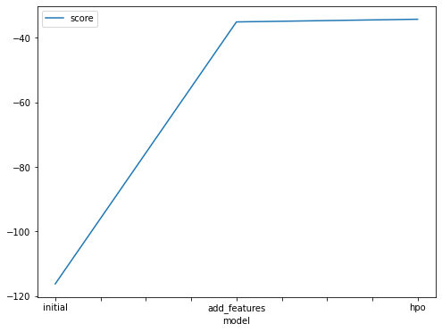

```python
# Taking the top model score from each training run and creating a line plot to show improvement
# You can create these in the notebook and save them to PNG or use some other tool (e.g. google sheets, excel)
fig = pd.DataFrame(
    {
        "model": ["initial", "add_features", "hpo"],
        "score": [-116.187513, -35.107319, -34.278285]
    }
).plot(x="model", y="score", figsize=(8, 6)).get_figure()
fig.savefig('model_train_score.png')
```

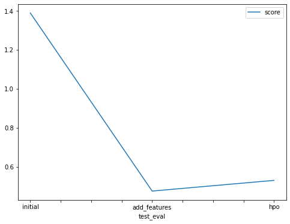

```python
# Take the 3 kaggle scores and creating a line plot to show improvement
fig = pd.DataFrame(
    {
        "test_eval": ["initial", "add_features", "hpo"],
        "score": [1.38918 , 0.47469, 0.52957 ]
    }
).plot(x="test_eval", y="score", figsize=(8, 6)).get_figure()
fig.savefig('model_test_score.png')
```

### Hyperparameter table

```python
# The 3 hyperparameters we tuned with the kaggle score as the result
pd.DataFrame({
    "model": ["initial", "add_features", "hpo"],
    "hpo1": [None, None, {'GBM':{'num_iterations':300, 'learning_rate':0.15}}],
    "hpo2": [None, None, {'XGB':{'objective':'reg:squarederror', 'max_depth':8, 'eta':0.37}}],
    "hpo3": [None, None, {'CAT':{'depth':10,'learning_rate':0.11}}],
    "score": [1.38918 , 0.47469, 0.52957]
})
```

|  | model | hpo1 | hpo2 | hpo3 | score |
| --- | --- | --- | --- | --- | --- |
| 0 | initial | None | None | None | 1.38918 |
| 1 | add_features | None | None | None | 0.47469 |
| 2 | hpo | {'GBM': {'num_iterations': 300, 'learning_rate': 0.15}} | {'XGB': {'objective': 'reg:squarederror', 'max_depth': 8, 'eta': 0.37}} | {'CAT': {'depth': 10, 'learning_rate': 0.11}} | 0.52957 |

## Standout suggestions

### plot model training performance for all the models

```python
# standout suggestions
#1- Add more than one features to dataset and train models
train["holiday"]= train["holiday"].astype('category')
train["workingday"]= train["workingday"].astype('category')
test["holiday"]= test["holiday"].astype('category')
test["workingday"]= test["workingday"].astype('category')
test.info()
```

```
<class 'pandas.core.frame.DataFrame'>
RangeIndex: 6493 entries, 0 to 6492
Data columns (total 13 columns):
 #   Column      Non-Null Count  Dtype
---  ------      --------------  -----
 0   datetime    6493 non-null   datetime64[ns]
 1   season      6493 non-null   category
 2   holiday     6493 non-null   category
 3   workingday  6493 non-null   category
 4   weather     6493 non-null   category
 5   temp        6493 non-null   float64
 6   atemp       6493 non-null   float64
 7   humidity    6493 non-null   int64
 8   windspeed   6493 non-null   float64
 9   year        6493 non-null   int64
 10  hour        6493 non-null   int64
 11  month       6493 non-null   int64
 12  day         6493 non-null   int64
dtypes: category(4), datetime64[ns](1), float64(3), int64(5)
memory usage: 482.7 KB
```

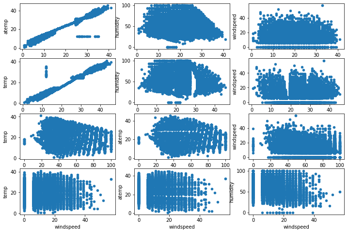

```python
#plot correlation matrix
train.corr()
import matplotlib.pyplot as plt
fig, axes = plt.subplots(nrows= 4,ncols=3, figsize=(12,8))
train.plot(ax=axes[0, 0], x= 'temp', y='atemp', kind="scatter")
train.plot(ax=axes[0, 1], x= 'temp', y='humidity', kind="scatter")
train.plot(ax=axes[0, 2], x= 'temp', y='windspeed', kind="scatter")
train.plot(ax=axes[1,0], x= 'atemp', y='temp', kind="scatter")
train.plot(ax=axes[1,1], x= 'atemp', y='humidity', kind="scatter")
train.plot(ax=axes[1,2], x= 'atemp', y='windspeed', kind="scatter")
train.plot(ax=axes[2, 0], x= 'humidity', y='temp', kind="scatter")
train.plot(ax=axes[2, 1], x= 'humidity', y='atemp', kind="scatter")
train.plot(ax=axes[2, 2], x= 'humidity', y='windspeed', kind="scatter")
train.plot(ax=axes[3, 0], x= 'windspeed', y='temp', kind="scatter")
train.plot(ax=axes[3, 1], x= 'windspeed', y='atemp', kind="scatter")
train.plot(ax=axes[3, 2], x= 'windspeed', y='humidity', kind="scatter")
```

```python
#Train model with new features
predictor_new_features = TabularPredictor(label='count', eval_metric='root_mean_squared_error').fit(train_data= train, time_limit=600, presets='best_quality')
```

```
No path specified. Models will be saved in: "AutogluonModels/ag-20220214_010840/"
Presets specified: ['best_quality']
Beginning AutoGluon training ... Time limit = 600s
AutoGluon will save models to "AutogluonModels/ag-20220214_010840/"
AutoGluon Version:  0.3.1
Train Data Rows:    10886
Train Data Columns: 13
Preprocessing data ...
AutoGluon infers your prediction problem is: 'regression' (because dtype of label-column == int and many unique label-values observed).
	Label info (max, min, mean, stddev): (977, 1, 191.57413, 181.14445)
	If 'regression' is not the correct problem_type, please manually specify the problem_type argument in fit() (You may specify problem_type as one of: ['binary', 'multiclass', 'regression'])
Using Feature Generators to preprocess the data ...
Fitting AutoMLPipelineFeatureGenerator...
	Available Memory:                    882.79 MB
	Train Data (Original)  Memory Usage: 0.83 MB (0.1% of available memory)
	Inferring data type of each feature based on column values. Set feature_metadata_in to manually specify special dtypes of the features.
	Stage 1 Generators:
		Fitting AsTypeFeatureGenerator...
			Note: Converting 3 features to boolean dtype as they only contain 2 unique values.
	Stage 2 Generators:
		Fitting FillNaFeatureGenerator...
	Stage 3 Generators:
		Fitting IdentityFeatureGenerator...
		Fitting CategoryFeatureGenerator...
			Fitting CategoryMemoryMinimizeFeatureGenerator...
		Fitting DatetimeFeatureGenerator...
	Stage 4 Generators:
		Fitting DropUniqueFeatureGenerator...
	Types of features in original data (raw dtype, special dtypes):
		('category', []) : 4 | ['season', 'holiday', 'workingday', 'weather']
		('datetime', []) : 1 | ['datetime']
		('float', [])    : 3 | ['temp', 'atemp', 'windspeed']
		('int', [])      : 5 | ['humidity', 'year', 'hour', 'month', 'day']
	Types of features in processed data (raw dtype, special dtypes):
		('category', [])             : 2 | ['season', 'weather']
		('float', [])                : 3 | ['temp', 'atemp', 'windspeed']
		('int', [])                  : 4 | ['humidity', 'hour', 'month', 'day']
		('int', ['bool'])            : 3 | ['holiday', 'workingday', 'year']
		('int', ['datetime_as_int']) : 1 | ['datetime']
	0.1s = Fit runtime
	13 features in original data used to generate 13 features in processed data.
	Train Data (Processed) Memory Usage: 0.75 MB (0.1% of available memory)
Data preprocessing and feature engineering runtime = 0.15s ...
AutoGluon will gauge predictive performance using evaluation metric: 'root_mean_squared_error'
	To change this, specify the eval_metric argument of fit()
AutoGluon will fit 2 stack levels (L1 to L2) ...
Fitting 11 L1 models ...
Fitting model: KNeighborsUnif_BAG_L1 ... Training model for up to 399.8s of the 599.84s of remaining time.
	-123.9226	 = Validation score   (root_mean_squared_error)
	0.03s	 = Training   runtime
	0.2s	 = Validation runtime
Fitting model: KNeighborsDist_BAG_L1 ... Training model for up to 399.31s of the 599.36s of remaining time.
	-119.3734	 = Validation score   (root_mean_squared_error)
	0.02s	 = Training   runtime
	0.2s	 = Validation runtime
Fitting model: LightGBMXT_BAG_L1 ... Training model for up to 398.85s of the 598.89s of remaining time.
```

```
[1000]	train_set's rmse: 30.2477	valid_set's rmse: 37.5245
[2000]	train_set's rmse: 25.3001	valid_set's rmse: 36.0436
[3000]	train_set's rmse: 22.5451	valid_set's rmse: 35.7329
[4000]	train_set's rmse: 20.604	valid_set's rmse: 35.5579
[5000]	train_set's rmse: 19.0933	valid_set's rmse: 35.5226
```

```
[1000]	train_set's rmse: 30.2855	valid_set's rmse: 41.5672
[2000]	train_set's rmse: 25.4432	valid_set's rmse: 39.4708
[3000]	train_set's rmse: 22.7451	valid_set's rmse: 38.63
[4000]	train_set's rmse: 20.83	valid_set's rmse: 38.1891
[5000]	train_set's rmse: 19.3595	valid_set's rmse: 37.9911
[6000]	train_set's rmse: 18.078	valid_set's rmse: 37.8675
[7000]	train_set's rmse: 17.0434	valid_set's rmse: 37.7975
[8000]	train_set's rmse: 16.1117	valid_set's rmse: 37.714
[9000]	train_set's rmse: 15.2917	valid_set's rmse: 37.6917
[10000]	train_set's rmse: 14.5662	valid_set's rmse: 37.6263
```

```
[1000]	train_set's rmse: 30.5723	valid_set's rmse: 35.183
[2000]	train_set's rmse: 25.5654	valid_set's rmse: 34.1873
[3000]	train_set's rmse: 22.8284	valid_set's rmse: 34.1413
```

```
[1000]	train_set's rmse: 30.1978	valid_set's rmse: 40.8555
[2000]	train_set's rmse: 25.2874	valid_set's rmse: 39.2459
[3000]	train_set's rmse: 22.6566	valid_set's rmse: 38.7255
[4000]	train_set's rmse: 20.7635	valid_set's rmse: 38.4024
[5000]	train_set's rmse: 19.3121	valid_set's rmse: 38.2055
[6000]	train_set's rmse: 18.0987	valid_set's rmse: 38.0455
[7000]	train_set's rmse: 17.0244	valid_set's rmse: 37.8859
[8000]	train_set's rmse: 16.1316	valid_set's rmse: 37.7573
[9000]	train_set's rmse: 15.3347	valid_set's rmse: 37.6728
[10000]	train_set's rmse: 14.6031	valid_set's rmse: 37.6167
```

```
[1000]	train_set's rmse: 30.5834	valid_set's rmse: 38.3338
[2000]	train_set's rmse: 25.368	valid_set's rmse: 36.8213
[3000]	train_set's rmse: 22.6318	valid_set's rmse: 36.4373
[4000]	train_set's rmse: 20.688	valid_set's rmse: 36.3476
```

```
[1000]	train_set's rmse: 30.0456	valid_set's rmse: 41.6063
[2000]	train_set's rmse: 25.2807	valid_set's rmse: 40.4318
[3000]	train_set's rmse: 22.5682	valid_set's rmse: 40.2374
```

```
[1000]	train_set's rmse: 30.6638	valid_set's rmse: 39.008
[2000]	train_set's rmse: 25.6578	valid_set's rmse: 36.2636
[3000]	train_set's rmse: 22.9076	valid_set's rmse: 35.3631
[4000]	train_set's rmse: 20.8966	valid_set's rmse: 34.9365
[5000]	train_set's rmse: 19.3187	valid_set's rmse: 34.7854
[6000]	train_set's rmse: 18.0319	valid_set's rmse: 34.6856
[7000]	train_set's rmse: 16.9637	valid_set's rmse: 34.7055
```

```
[1000]	train_set's rmse: 30.2841	valid_set's rmse: 38.6973
[2000]	train_set's rmse: 25.3801	valid_set's rmse: 37.3003
[3000]	train_set's rmse: 22.6615	valid_set's rmse: 36.9534
[4000]	train_set's rmse: 20.748	valid_set's rmse: 36.7291
[5000]	train_set's rmse: 19.2405	valid_set's rmse: 36.5964
[6000]	train_set's rmse: 17.961	valid_set's rmse: 36.4937
[7000]	train_set's rmse: 16.912	valid_set's rmse: 36.4327
[8000]	train_set's rmse: 16.0178	valid_set's rmse: 36.4359
[9000]	train_set's rmse: 15.226	valid_set's rmse: 36.4932
```

```
[1000]	train_set's rmse: 30.2788	valid_set's rmse: 41.6075
[2000]	train_set's rmse: 25.3554	valid_set's rmse: 40.4776
[3000]	train_set's rmse: 22.6646	valid_set's rmse: 40.3757
```

```
[1000]	train_set's rmse: 30.9236	valid_set's rmse: 36.9172
[2000]	train_set's rmse: 25.7371	valid_set's rmse: 34.9063
[3000]	train_set's rmse: 22.9803	valid_set's rmse: 34.4039
[4000]	train_set's rmse: 21.0473	valid_set's rmse: 34.1593
[5000]	train_set's rmse: 19.5384	valid_set's rmse: 33.9918
[6000]	train_set's rmse: 18.2716	valid_set's rmse: 33.9458
[7000]	train_set's rmse: 17.2106	valid_set's rmse: 33.8961
[8000]	train_set's rmse: 16.2805	valid_set's rmse: 33.882
```

```
	-36.7176	 = Validation score   (root_mean_squared_error)
	100.56s	 = Training   runtime
	4.86s	 = Validation runtime
Fitting model: LightGBM_BAG_L1 ... Training model for up to 282.38s of the 482.42s of remaining time.
```

```
[1000]	train_set's rmse: 21.1363	valid_set's rmse: 35.556
[2000]	train_set's rmse: 15.5229	valid_set's rmse: 35.4489
```

```
[1000]	train_set's rmse: 21.0431	valid_set's rmse: 36.9388
[2000]	train_set's rmse: 15.5393	valid_set's rmse: 36.1223
[3000]	train_set's rmse: 12.2068	valid_set's rmse: 35.9677
[4000]	train_set's rmse: 9.97753	valid_set's rmse: 35.9639
```

```
[1000]	train_set's rmse: 21.4253	valid_set's rmse: 33.0295
```

```
[1000]	train_set's rmse: 21.4591	valid_set's rmse: 38.0987
[2000]	train_set's rmse: 15.6967	valid_set's rmse: 37.1129
[3000]	train_set's rmse: 12.2044	valid_set's rmse: 36.7212
[4000]	train_set's rmse: 9.95476	valid_set's rmse: 36.6786
```

```
[1000]	train_set's rmse: 21.43	valid_set's rmse: 37.371
[2000]	train_set's rmse: 15.5136	valid_set's rmse: 36.986
```

```
[1000]	train_set's rmse: 21.6619	valid_set's rmse: 35.9541
```

```
[1000]	train_set's rmse: 21.0051	valid_set's rmse: 35.6024
[2000]	train_set's rmse: 15.4015	valid_set's rmse: 34.9824
```

```
[1000]	train_set's rmse: 21.3287	valid_set's rmse: 36.3245
[2000]	train_set's rmse: 15.6834	valid_set's rmse: 35.8282
[3000]	train_set's rmse: 12.2992	valid_set's rmse: 35.5694
[4000]	train_set's rmse: 10.1773	valid_set's rmse: 35.5318
```

```
	-36.5863	 = Validation score   (root_mean_squared_error)
	38.92s	 = Training   runtime
	1.31s	 = Validation runtime
Fitting model: RandomForestMSE_BAG_L1 ... Training model for up to 237.99s of the 438.04s of remaining time.
	Warning: Reducing model 'n_estimators' from 300 -> 161 due to low memory. Expected memory usage reduced from 27.89% -> 15.0% of available memory...
	-41.6056	 = Validation score   (root_mean_squared_error)
	5.3s	 = Training   runtime
	0.22s	 = Validation runtime
Fitting model: CatBoost_BAG_L1 ... Training model for up to 231.41s of the 431.46s of remaining time.
	Time limit exceeded... Skipping CatBoost_BAG_L1.
Fitting model: ExtraTreesMSE_BAG_L1 ... Training model for up to 201.03s of the 401.08s of remaining time.
	Warning: Reducing model 'n_estimators' from 300 -> 147 due to low memory. Expected memory usage reduced from 30.52% -> 15.0% of available memory...
	-41.5025	 = Validation score   (root_mean_squared_error)
	1.98s	 = Training   runtime
	0.2s	 = Validation runtime
Fitting model: NeuralNetFastAI_BAG_L1 ... Training model for up to 197.96s of the 398.01s of remaining time.
	-46.1558	 = Validation score   (root_mean_squared_error)
	128.46s	 = Training   runtime
	0.35s	 = Validation runtime
Fitting model: XGBoost_BAG_L1 ... Training model for up to 68.34s of the 268.38s of remaining time.
	-37.4173	 = Validation score   (root_mean_squared_error)
	32.62s	 = Training   runtime
	0.34s	 = Validation runtime
Fitting model: NeuralNetMXNet_BAG_L1 ... Training model for up to 31.84s of the 231.88s of remaining time.
	Ran out of time, stopping training early. (Stopping on epoch 0)
	Ran out of time, stopping training early. (Stopping on epoch 0)
	Ran out of time, stopping training early. (Stopping on epoch 0)
	Ran out of time, stopping training early. (Stopping on epoch 0)
	Ran out of time, stopping training early. (Stopping on epoch 0)
	Ran out of time, stopping training early. (Stopping on epoch 0)
	Ran out of time, stopping training early. (Stopping on epoch 0)
	Ran out of time, stopping training early. (Stopping on epoch 0)
	Ran out of time, stopping training early. (Stopping on epoch 0)
	Ran out of time, stopping training early. (Stopping on epoch 1)
	-280.4009	 = Validation score   (root_mean_squared_error)
	24.7s	 = Training   runtime
	6.25s	 = Validation runtime
Fitting model: LightGBMLarge_BAG_L1 ... Training model for up to 0.27s of the 200.31s of remaining time.
	Ran out of time, early stopping on iteration 1. Best iteration is:
	[1]	train_set's rmse: 176.305	valid_set's rmse: 174.668
```

[output cut: 38 more lines]

```
	Ran out of time, stopping training early. (Stopping on epoch 29)
	-35.7202	 = Validation score   (root_mean_squared_error)
	105.85s	 = Training   runtime
	0.38s	 = Validation runtime
Fitting model: XGBoost_BAG_L2 ... Training model for up to 6.85s of the 6.83s of remaining time.
	-36.3544	 = Validation score   (root_mean_squared_error)
	6.11s	 = Training   runtime
	0.12s	 = Validation runtime
Completed 1/20 k-fold bagging repeats ...
Fitting model: WeightedEnsemble_L3 ... Training model for up to 360.0s of the -0.19s of remaining time.
	-35.1329	 = Validation score   (root_mean_squared_error)
	0.36s	 = Training   runtime
	0.0s	 = Validation runtime
AutoGluon training complete, total runtime = 600.79s ...
TabularPredictor saved. To load, use: predictor = TabularPredictor.load("AutogluonModels/ag-20220214_010840/")
```

```python
predictor_sto_features.fit_summary()
```

[output not shown]

[output not shown]

[output cut: 163 more lines]

```
 2          14
 3          15
 4          12
 5          16
 6          13
 7          11
 8           4
 9           3
 10          8
 11          6
 12          5
 13          7
 14          2
 15          1
 16          9  }
```

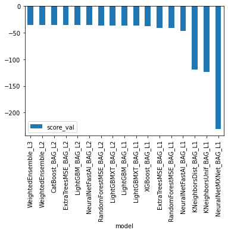

```python
# plot model training performance wtith more than just the top model
predictor_sto_features.leaderboard(silent=True).plot(kind="bar", x="model", y="score_val")
```

```python
predictions_sto_features = predictor_sto_features.predict(test)
predictions_sto_features.describe()
```

```
count    6493.000000
mean      189.997223
std       172.783157
min        -0.084840
25%        47.545341
50%       147.763046
75%       282.527924
max       880.642578
Name: count, dtype: float64
```

```python
sum =0
for prediction in predictions_sto_features:
    if prediction<0:
        sum +=1
print(sum)
```

```
1
```

```python
predictions_sto_features.loc[predictions_sto_features<0]= 0
submission_sto_features= pd.read_csv("sampleSubmission.csv")
submission_sto_features.loc[:, "datetime"] = pd.to_datetime(submission_sto_features.loc[:, "datetime"])
submission_sto_features["count"] = predictions_sto_features
submission_sto_features.to_csv("submission_sto_features.csv", index=False)
```

```python
!kaggle competitions submit -c bike-sharing-demand -f submission_sto_features.csv -m "standout suggestion new features"
```

```
Successfully submitted to Bike Sharing Demand
```

```python
!kaggle competitions submissions -c bike-sharing-demand | tail -n +1 | head -n 6
```

```
fileName                     date                 description                          status    publicScore  privateScore
---------------------------  -------------------  -----------------------------------  --------  -----------  ------------
submission_sto_features.csv  2022-02-14 01:22:08  standout suggestion new features     complete  0.47203      0.47203
submission_new_hpo.csv       2022-02-14 01:02:14  new features with hyperparameters    complete  0.52957      0.52957
submission_new_features.csv  2022-02-14 00:51:53  new features                         complete  0.47469      0.47469
submission.csv               2022-02-14 00:38:20  first raw submission                 complete  1.38918      1.38918
```

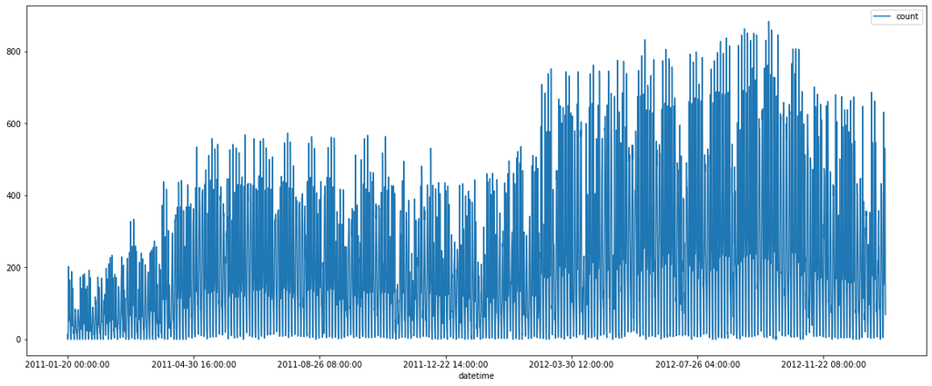

```python
#time series of bike-sharing demand
series= pd.read_csv("submission_new_hpo.csv")
series.plot(kind="line", x='datetime', y="count", figsize=(20,8)).get_figure().savefig('bike_sharing_demand_timeseries.png')
```